# Emulating Majorana fermions braiding on an Ising chain

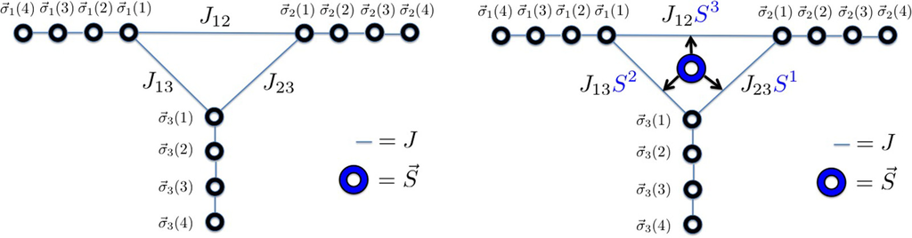

Usual approach requires to go beyond 1D, here an extra coupling spin will allow to work in 1D.

## Model Hamiltonian

\begin{equation} H = -J \sum_i \sigma_{z, i}\,\sigma_{z, i+1} - \sum-i h_i\,\sigma_{x, i} - J_m \sigma_{z, m}\,\sigma_{z, m+1}\,S_x \end{equation}

Key ideas:

- ferromagnetic domain ($h \ll J$) = topological region
- adiabatic switching of $h_i$ allow to move the domain
- coupler spin S enable braiding in 1D

Logical basis for 3 spins: \begin{align} |0\rangle = \frac{|\uparrow\uparrow\uparrow\rangle + |\downarrow\downarrow\downarrow\rangle}{\sqrt{2}}\qquad |1\rangle = \frac{|\uparrow\uparrow\uparrow\rangle - |\downarrow\downarrow\downarrow\rangle}{\sqrt{2}} \end{align}

Map physical qubit $|0\rangle$ to $|\uparrow\rangle$

*S. Backens et al., Emulating Majorana fermions and their braiding by Ising spin chains. Physical Review B. 96 (2017), doi:10.1103/PhysRevB.96.195402.*

*Marek Mateusz Narozniak & Tim Byrnes*

[figure not shown]

## Implementation

- Suzuki-Trotter decomposition handle $\mathcal{H}$
- adiabatic switching implemented by incremental updates of $h_i$
- coupler prepared by applying $S_x(\pi)$, then after first transfer apply $S_y(\theta)$ give a phase gate of angle theta

$\rightarrow$ Braiding studied on $|\uparrow\uparrow\uparrow\rangle$ with $\theta = \pi$

$\Rightarrow$ high computational cost (depth > 60000 gates before optimization) but system quite tolerant to large steps

```python
import numpy as np
from qiskit.circuit import QuantumCircuit, QuantumRegister, ClassicalRegister
from ising_kitaev.trotter import interaction_hamiltonian, chain_hamiltonian
qreg = QuantumRegister(5)
qcirc = QuantumCircuit(qreg)
chain_hamiltonian(qcirc, qreg, 0.1, np.array([10, 0.1, 0.1, 0.1])/10, True)
print(qcirc.draw())
qcirc = QuantumCircuit(qreg)
interaction_hamiltonian(qcirc, qreg, 1, 2, 0.14)
print(qcirc.draw())
```

```
                                                    ░ ┌──────────┐ ░
q0_0: |0>──■───────────────■────────────────────────░─┤  Rx(1)   ├─░─
         ┌─┴─┐┌─────────┐┌─┴─┐                      ░ ├──────────┤ ░
q0_1: |0>┤ X ├┤ U1(0.1) ├┤ X ├──■───────────────■───░─┤ Rx(0.01) ├─░─
         └───┘└─────────┘└───┘┌─┴─┐┌─────────┐┌─┴─┐ ░ ├──────────┤ ░
q0_2: |0>──■───────────────■──┤ X ├┤ U1(0.1) ├┤ X ├─░─┤ Rx(0.01) ├─░─
         ┌─┴─┐┌─────────┐┌─┴─┐└───┘└─────────┘└───┘ ░ ├──────────┤ ░
q0_3: |0>┤ X ├┤ U1(0.1) ├┤ X ├──────────────────────░─┤ Rx(0.01) ├─░─
         └───┘└─────────┘└───┘                      ░ └──────────┘ ░
q0_4: |0>───────────────────────────────────────────░──────────────░─
                                                    ░              ░

q0_0: |0>─────────────────────────────────
         ┌───┐                       ┌───┐
q0_1: |0>┤ X ├──■─────────────────■──┤ X ├
         └─┬─┘  │                 │  └─┬─┘
q0_2: |0>──■────┼─────────────────┼────■──
                │                 │
q0_3: |0>───────┼─────────────────┼───────
         ┌───┐┌─┴─┐┌───────────┐┌─┴─┐┌───┐
q0_4: |0>┤ H ├┤ X ├┤ Rz(-0.14) ├┤ X ├┤ H ├
         └───┘└───┘└───────────┘└───┘└───┘
```

## Outcome

- chain expansion, chain contraction, chain moving: $|1>$ moved on a chain of 6 with > 90% probability without coupler
- with coupler reduced probabibility: bad decoupling ?
- full braiding possible: outcome 70% probability between $|\uparrow\uparrow\uparrow\rangle$ and $|\downarrow\downarrow\downarrow\rangle$ (chain of 8/12 spins 3 sites ferro, specific time evolution parameters)
- longer topological area do not perform as well, coupler issue

*Few evolution parameters tested so we may have been lucky*

**Qiskit provides a nice simulation platform for condensed matter**